# Lab4

Andrew Bartnik

2023-05-02

This data set includes more possible predictors than the text alone, but for this model we will only use the text variable

```r
urlfile ="https://raw.githubusercontent.com/MaRo406/EDS-231-text-sentiment/main/data/climbing_reports_model_dat.csv"
incidents_df<-readr::read_csv(url(urlfile))
```

Now we’ll split our data into training and test portions

```r
set.seed(1234)
incidents2class <- incidents_df %>%
  mutate(fatal = factor(if_else(
    is.na(Deadly) ,
    "non-fatal", "fatal")))

incidents_split <- initial_split(incidents2class, strata = fatal)

incidents_train <- training(incidents_split)
incidents_test <- testing(incidents_split)
```

We use recipe() to specify the predictor and outcome variables and the data.

```r
incidents_rec <- recipe(fatal ~ Text, data = incidents_train)
```

Next we add some familiar pre-processing steps on our Text variable: tokenize to word level, filter to the most common words, and calculate tf-idf.

```r
recipe <- incidents_rec %>%
  step_tokenize(Text) %>%
  step_tokenfilter(Text, max_tokens = 1000) %>%
  step_tfidf(Text) #new one from textrecipes
```

Create tidymodels workflow to combine the modeling components

The advantages are: You don’t have to keep track of separate objects in your workspace. The recipe prepping and model fitting can be executed using a single call to fit() . If you have custom tuning parameter settings, these can be defined using a simpler interface when combined with tune.

```r
incidents_wf <- workflow() %>%
  add_recipe(recipe)
```

```r
nb_spec <- naive_Bayes() %>%
  set_mode("classification") %>% #set modeling context
  set_engine("naivebayes") #method for fitting model

nb_spec
```

```
## Naive Bayes Model Specification (classification)
##
## Computational engine: naivebayes
```

Now we are ready to add our model to the workflow and fit it to the training data

```r
nb_fit <- incidents_wf %>%
  add_model(nb_spec) %>%
  fit(data = incidents_train)
```

Next up is model evaluation. We’ll stretch our training data further and use resampling to evaluate our naive Bayes model. Here we create 10-fold cross-validation sets, and use them to estimate performance.

```r
set.seed(234)
incidents_folds <- vfold_cv(incidents_train) #default is v = 10

incidents_folds
```

```
## #  10-fold cross-validation
## # A tibble: 10 × 2
##    splits             id
##    <list>             <chr>
##  1 <split [1869/208]> Fold01
##  2 <split [1869/208]> Fold02
##  3 <split [1869/208]> Fold03
##  4 <split [1869/208]> Fold04
##  5 <split [1869/208]> Fold05
##  6 <split [1869/208]> Fold06
##  7 <split [1869/208]> Fold07
##  8 <split [1870/207]> Fold08
##  9 <split [1870/207]> Fold09
## 10 <split [1870/207]> Fold10
```

```r
nb_wf <- workflow() %>%
  add_recipe(recipe) %>%
  add_model(nb_spec)

nb_wf
```

```
## ══ Workflow ════════════════════════════════════════════════════════════════════
## Preprocessor: Recipe
## Model: naive_Bayes()
##
## ── Preprocessor ────────────────────────────────────────────────────────────────
## 3 Recipe Steps
##
## • step_tokenize()
## • step_tokenfilter()
## • step_tfidf()
##
## ── Model ───────────────────────────────────────────────────────────────────────
## Naive Bayes Model Specification (classification)
##
## Computational engine: naivebayes
```

To estimate its performance, we fit the model many times, once to each of these resampled folds, and then evaluate on the heldout part of each resampled fold.

```r
nb_rs <- fit_resamples(
  nb_wf,
  incidents_folds,
  control = control_resamples(save_pred = TRUE)
)
```

Extract the relevant information using collect_metrics() and collect_predictions() and examine the performance metrics.

```r
nb_rs_metrics <- collect_metrics(nb_rs)
nb_rs_predictions <- collect_predictions(nb_rs)
nb_rs_metrics
```

```
## # A tibble: 2 × 6
##   .metric  .estimator  mean     n std_err .config
##   <chr>    <chr>      <dbl> <int>   <dbl> <chr>
## 1 accuracy binary     0.800    10 0.00474 Preprocessor1_Model1
## 2 roc_auc  binary     0.730    10 0.0118  Preprocessor1_Model1
```

We’ll use two performance metrics: accuracy and ROC AUC. Accuracy is the proportion of the data that is predicted correctly. The ROC curve plots the true positive rate against the false positive rate; AUC closer to 1 indicates a better-performing model, while AUC closer to 0.5 indicates a model that does no better than random guessing.

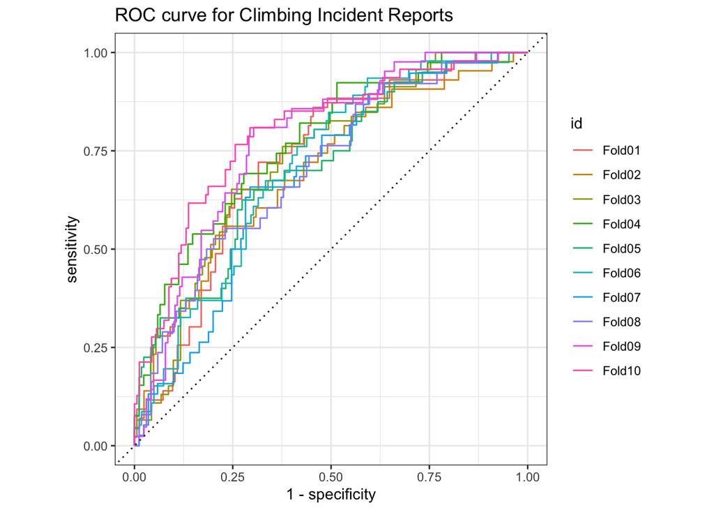

```r
nb_rs_predictions %>%
  group_by(id) %>%
  roc_curve(truth = fatal, .pred_fatal) %>%
  autoplot() +
  labs(
    "Resamples",
    title = "ROC curve for Climbing Incident Reports"
  )
```

Another model method involves the confusion matrix. A confusion matrix tabulates a model’s false positives and false negatives for each class.

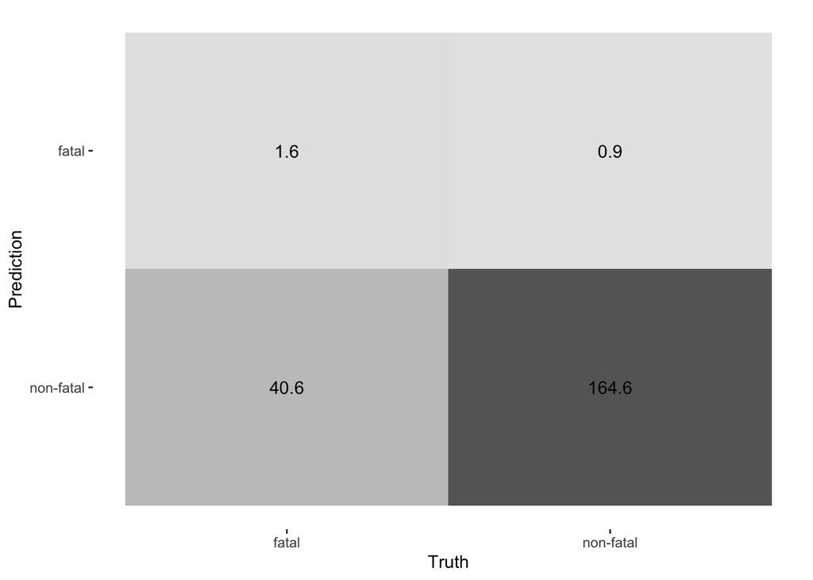

```r
conf_mat_resampled(nb_rs, tidy = FALSE) %>% #compute matrix for each fold then average
  autoplot(type = "heatmap")
```

```r
lasso_spec <- logistic_reg(penalty = 0.01, mixture =1) |>
  set_mode('classification') |>
  set_engine("glmnet")

lasso_wf <- workflow() |>
  add_recipe(recipe) |>
  add_model(lasso_spec)

lasso_wf
```

```
## ══ Workflow ════════════════════════════════════════════════════════════════════
## Preprocessor: Recipe
## Model: logistic_reg()
##
## ── Preprocessor ────────────────────────────────────────────────────────────────
## 3 Recipe Steps
##
## • step_tokenize()
## • step_tokenfilter()
## • step_tfidf()
##
## ── Model ───────────────────────────────────────────────────────────────────────
## Logistic Regression Model Specification (classification)
##
## Main Arguments:
##   penalty = 0.01
##   mixture = 1
##
## Computational engine: glmnet
```

```r
set.seed(123)
lasso_rs <- fit_resamples(
  lasso_wf,
  incidents_folds,
  control = control_resamples(save_pred = T)
)

lasso_rs_metrics <- collect_metrics(lasso_rs)
lasso_rs_predictions <- collect_predictions(lasso_rs)
```

```r
lasso_rs_metrics
```

```
## # A tibble: 2 × 6
##   .metric  .estimator  mean     n std_err .config
##   <chr>    <chr>      <dbl> <int>   <dbl> <chr>
## 1 accuracy binary     0.895    10 0.00538 Preprocessor1_Model1
## 2 roc_auc  binary     0.947    10 0.00593 Preprocessor1_Model1
```

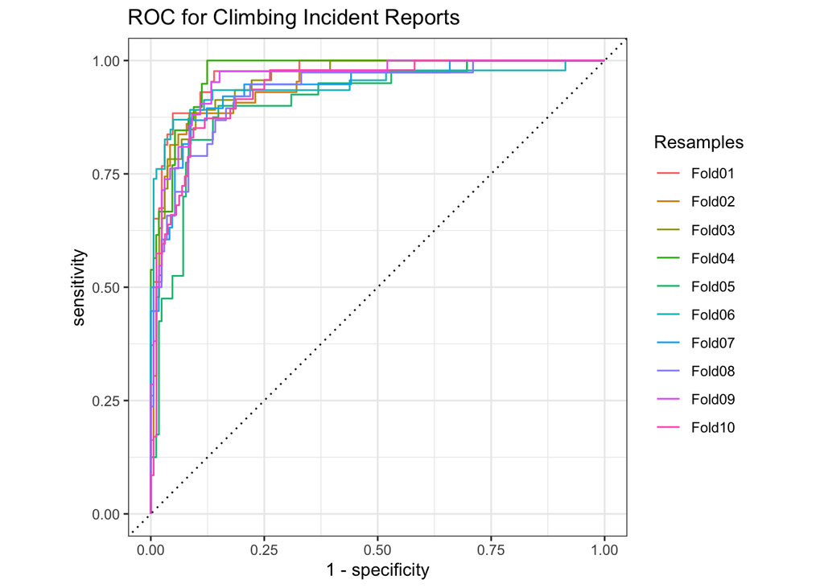

```r
lasso_rs_predictions |>
  group_by(id) |>
  roc_curve(truth = fatal, .pred_fatal) |>
  autoplot() + labs(color = "Resamples",
                    title = "ROC for Climbing Incident Reports")
```

```r
tune_spec <- logistic_reg(penalty = tune(), mixture = 1) |> set_mode("classification") |> set_engine("glmnet")

tune_spec
```

```
## Logistic Regression Model Specification (classification)
##
## Main Arguments:
##   penalty = tune()
##   mixture = 1
##
## Computational engine: glmnet
```

```r
tune_wf <- workflow() |>
  add_recipe(recipe) |>
  add_model(tune_spec)

set.seed(123)
lambda_grid <- grid_regular(penalty(), levels = 30)
tune_rs <- tune_grid(tune_wf, incidents_folds, grid = lambda_grid, control = control_resamples(save_pred = T))
```

```r
collect_metrics(tune_rs)
```

```
## # A tibble: 60 × 7
##     penalty .metric  .estimator  mean     n std_err .config
##       <dbl> <chr>    <chr>      <dbl> <int>   <dbl> <chr>
##  1 1   e-10 accuracy binary     0.889    10 0.00644 Preprocessor1_Model01
##  2 1   e-10 roc_auc  binary     0.921    10 0.00613 Preprocessor1_Model01
##  3 2.21e-10 accuracy binary     0.889    10 0.00644 Preprocessor1_Model02
##  4 2.21e-10 roc_auc  binary     0.921    10 0.00613 Preprocessor1_Model02
##  5 4.89e-10 accuracy binary     0.889    10 0.00644 Preprocessor1_Model03
##  6 4.89e-10 roc_auc  binary     0.921    10 0.00613 Preprocessor1_Model03
##  7 1.08e- 9 accuracy binary     0.889    10 0.00644 Preprocessor1_Model04
##  8 1.08e- 9 roc_auc  binary     0.921    10 0.00613 Preprocessor1_Model04
##  9 2.40e- 9 accuracy binary     0.889    10 0.00644 Preprocessor1_Model05
## 10 2.40e- 9 roc_auc  binary     0.921    10 0.00613 Preprocessor1_Model05
## # … with 50 more rows
```

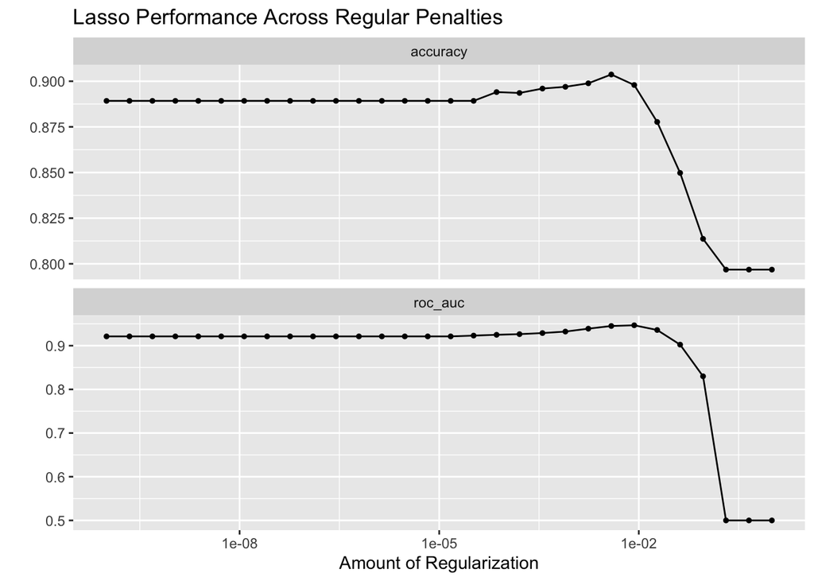

```r
autoplot(tune_rs) + labs(title = "Lasso Performance Across Regular Penalties")
```

```r
tune_rs |> show_best("roc_auc")
```

```
## # A tibble: 5 × 7
##    penalty .metric .estimator  mean     n std_err .config
##      <dbl> <chr>   <chr>      <dbl> <int>   <dbl> <chr>
## 1 0.00853  roc_auc binary     0.947    10 0.00586 Preprocessor1_Model24
## 2 0.00386  roc_auc binary     0.945    10 0.00532 Preprocessor1_Model23
## 3 0.00174  roc_auc binary     0.939    10 0.00500 Preprocessor1_Model22
## 4 0.0189   roc_auc binary     0.936    10 0.00596 Preprocessor1_Model25
## 5 0.000788 roc_auc binary     0.932    10 0.00527 Preprocessor1_Model21
```

```r
tune_rs |> show_best("accuracy")
```

```
## # A tibble: 5 × 7
##    penalty .metric  .estimator  mean     n std_err .config
##      <dbl> <chr>    <chr>      <dbl> <int>   <dbl> <chr>
## 1 0.00386  accuracy binary     0.904    10 0.00581 Preprocessor1_Model23
## 2 0.00174  accuracy binary     0.899    10 0.00672 Preprocessor1_Model22
## 3 0.00853  accuracy binary     0.898    10 0.00516 Preprocessor1_Model24
## 4 0.000788 accuracy binary     0.897    10 0.00624 Preprocessor1_Model21
## 5 0.000356 accuracy binary     0.896    10 0.00648 Preprocessor1_Model20
```

```r
collect_metrics(tune_rs)
```

```
## # A tibble: 60 × 7
##     penalty .metric  .estimator  mean     n std_err .config
##       <dbl> <chr>    <chr>      <dbl> <int>   <dbl> <chr>
##  1 1   e-10 accuracy binary     0.889    10 0.00644 Preprocessor1_Model01
##  2 1   e-10 roc_auc  binary     0.921    10 0.00613 Preprocessor1_Model01
##  3 2.21e-10 accuracy binary     0.889    10 0.00644 Preprocessor1_Model02
##  4 2.21e-10 roc_auc  binary     0.921    10 0.00613 Preprocessor1_Model02
##  5 4.89e-10 accuracy binary     0.889    10 0.00644 Preprocessor1_Model03
##  6 4.89e-10 roc_auc  binary     0.921    10 0.00613 Preprocessor1_Model03
##  7 1.08e- 9 accuracy binary     0.889    10 0.00644 Preprocessor1_Model04
##  8 1.08e- 9 roc_auc  binary     0.921    10 0.00613 Preprocessor1_Model04
##  9 2.40e- 9 accuracy binary     0.889    10 0.00644 Preprocessor1_Model05
## 10 2.40e- 9 roc_auc  binary     0.921    10 0.00613 Preprocessor1_Model05
## # … with 50 more rows
```

```r
chosen_acc <- tune_rs |> select_by_one_std_err(metric= "accuracy", -penalty)
final_lasso <- finalize_workflow(tune_wf, chosen_acc)

fitted_lasso <- fit(final_lasso, incidents_train)

fitted_lasso |> extract_fit_parsnip() |> tidy() |> arrange(estimate)
```

```
## # A tibble: 1,001 × 3
##    term                 estimate penalty
##    <chr>                   <dbl>   <dbl>
##  1 tfidf_Text_died        -277.  0.00853
##  2 tfidf_Text_body        -158.  0.00853
##  3 tfidf_Text_death       -132.  0.00853
##  4 tfidf_Text_fatal        -76.8 0.00853
##  5 tfidf_Text_breathing    -47.7 0.00853
##  6 tfidf_Text_past         -32.5 0.00853
##  7 tfidf_Text_observed     -32.5 0.00853
##  8 tfidf_Text_occurred     -31.7 0.00853
##  9 tfidf_Text_noticed      -31.1 0.00853
## 10 tfidf_Text_either       -31.0 0.00853
## # … with 991 more rows
```

```r
last_fit(final_lasso, incidents_split) |> collect_metrics()
```

```
## # A tibble: 2 × 4
##   .metric  .estimator .estimate .config
##   <chr>    <chr>          <dbl> <chr>
## 1 accuracy binary         0.916 Preprocessor1_Model1
## 2 roc_auc  binary         0.951 Preprocessor1_Model1
```

```r
fitted_lasso <- fit(final_lasso, incidents_train)

fitted_lasso |> extract_fit_parsnip() |> tidy() |> arrange(estimate)
```

```
## # A tibble: 1,001 × 3
##    term                 estimate penalty
##    <chr>                   <dbl>   <dbl>
##  1 tfidf_Text_died        -277.  0.00853
##  2 tfidf_Text_body        -158.  0.00853
##  3 tfidf_Text_death       -132.  0.00853
##  4 tfidf_Text_fatal        -76.8 0.00853
##  5 tfidf_Text_breathing    -47.7 0.00853
##  6 tfidf_Text_past         -32.5 0.00853
##  7 tfidf_Text_observed     -32.5 0.00853
##  8 tfidf_Text_occurred     -31.7 0.00853
##  9 tfidf_Text_noticed      -31.1 0.00853
## 10 tfidf_Text_either       -31.0 0.00853
## # … with 991 more rows
```

```r
last_fit(final_lasso, incidents_split) |> collect_metrics()
```

```
## # A tibble: 2 × 4
##   .metric  .estimator .estimate .config
##   <chr>    <chr>          <dbl> <chr>
## 1 accuracy binary         0.916 Preprocessor1_Model1
## 2 roc_auc  binary         0.951 Preprocessor1_Model1
```

# Lab 4 Assignment: Due May 9 at 11:59pm

1. Select another classification algorithm

## Random Forest Classifier

```r
rf_spec <- rand_forest() |> set_mode("classification") |> set_engine("ranger")
```

2. Conduct an initial out-of-the-box model fit on the training data and prediction on the test test data. Assess the performance of this initial model.

```r
rf_workflow <- workflow() |> add_recipe(recipe) |> add_model(rf_spec)
rf_fit <- rf_workflow |> fit(data = incidents_train)

rf_rs <- fit_resamples(
  rf_workflow,
  incidents_folds,
  control = control_resamples(save_pred = TRUE)
)
```

```r
rf_rs_metrics <- collect_metrics(rf_rs)
nb_rs_predictions <- collect_predictions(rf_rs)
rf_rs_metrics
```

```
## # A tibble: 2 × 6
##   .metric  .estimator  mean     n std_err .config
##   <chr>    <chr>      <dbl> <int>   <dbl> <chr>
## 1 accuracy binary     0.867    10 0.00668 Preprocessor1_Model1
## 2 roc_auc  binary     0.947    10 0.00400 Preprocessor1_Model1
```

**Initial model has an accuracy of 86% and roc_auc of 0.95. Not bad at all.**

3. Select the relevant hyperparameters for your algorithm and tune your model.

```r
tune_rf_spec <- rand_forest(trees = tune(), mtry = tune(), min_n = tune()) |> set_mode("classification") |> set_engine("ranger")

tune_rf_wf <- workflow() |>
  add_recipe(recipe) |>
  add_model(tune_rf_spec)

set.seed(123)
randf_grid <-grid_regular(trees(), min_n(), mtry(range(1:13)))
doParallel::registerDoParallel()
tune_rs <- tune_grid(tune_rf_wf, incidents_folds, grid = randf_grid, control = control_resamples(save_pred = T, parallel_over = 'everything'))
```

4. Conduct a model fit using your newly tuned model specification. What are the terms most highly associated with non-fatal reports? What about fatal reports?

```r
params <- tune_rs |> show_best("accuracy") |> slice(1) |> select(trees, mtry, min_n)
best_trees_rf <- params$trees
best_mtry_rf <- params$mtry
best_min_n_rf <- params$min_n

randf_final <- rand_forest(
  trees = best_trees_rf,
  mtry = best_mtry_rf,
  min_n = best_min_n_rf
) |>
  set_mode("classification") |>
  set_engine("ranger")


# fit on the training
randf_final_fit <- tune_rf_wf |>
  update_model(randf_final) |>
  fit(data = incidents_train)
```

**Unfortunately tidy doesnt support ranger and we are unable to see variable importance/terms most highly associated with different reports**

5. Predict fatality of the reports in the test set. Compare this prediction performance to that of the Naive Bayes and Lasso models.

```r
# predict on the test, calculate RMSE
rf_testing_preds <- predict(randf_final_fit, incidents_test) |>
  bind_cols(incidents_test) |>
  mutate(truth = as.factor(fatal), estimate = as.factor(.pred_class)) |>
  metrics(truth = truth, estimate = estimate)

rf_testing_preds
```

```
## # A tibble: 2 × 3
##   .metric  .estimator .estimate
##   <chr>    <chr>          <dbl>
## 1 accuracy binary         0.812
## 2 kap      binary         0.119
```